# Customer Churn Analysis

```r
# Load libraries
library(tidyverse)
library(rpart)
library(rpart.plot)
library(caret)
library(factoextra)
library(reshape2)
```

# **Introduction**

This report investigates telecom customer churn patterns using a large dataset (n=440,833) containing 12 variables. The dataset includes demographic features, subscription information, service usage patterns, and financial behavior.

Building on EDA findings, predictive modeling and customer segmentation techniques were applied to identify key factors driving customer churn and recognize distinct high-risk segments. The goal is to develop actionable retention strategies focused on at-risk customers.

## **Business Questions**

- Which factors best predict customer churn?
- What are the characteristics of high-risk customers?
- How can we develop targeted retention strategies?

## EDA Overview

- Only one row had missing values.
- No outliers were detected in numerical variables.
- Overall churn rate was 56.7%.
- **Support calls** had the strongest positive correlation with churn (0.57).
- **Total spend** showed a moderate negative correlation with churn (-0.43).
- **Monthly contracts** had a nearly 100% churn rate compared to quarterly/annual contracts.
- **Female customers** had higher churn rates (66.7%) than male customers (49.1%).

## **Approach**

**1. Prediction with Decision Trees -** to identify key drivers of churn

Easy to generate clear, interpretable rules for business stakeholders.

**2.** **Segmentation with K-means Clustering** - to identify distinct customer groups

Useful for uncovering segments with varying churn risks and defining characteristics for targeted retention.

## Data Preparation

This process primarily included standardizing column names, removing identifiers, checking and removing missing or duplicate values.

```r
# Load the dataset
churn <- read_csv("customer_churn_dataset-training-master.csv",
                  show_col_types = FALSE)

# Standardize column names
names(churn) <- tolower(gsub("[[:space:]]+|\\.", "_", names(churn)))

# Remove customer id
churn <- churn %>%
  select(-customerid)

# Identify missing values
colSums(is.na(churn))
```

```
##               age            gender            tenure   usage_frequency
##                 1                 1                 1                 1
##     support_calls     payment_delay subscription_type   contract_length
##                 1                 1                 1                 1
##       total_spend  last_interaction             churn
##                 1                 1                 1
```

```r
# Remove missing values
churn <- na.omit(churn)

# Verify no missing values remain
sum(is.na(churn))
```

```
## [1] 0
```

```r
# Check duplicate rows
sum(duplicated(churn))
```

```
## [1] 0
```

# **Decision Tree Analysis**

## Data Preprocessing

```r
# Convert categorical variables to factors
churn <- churn %>%
  mutate(gender = as.factor(gender),
         subscription_type = as.factor(subscription_type),
         contract_length = as.factor(contract_length),
         churn = as.factor(churn)
  )
```

## Split Dataset

The dataset was split into training (70%) and testing (30%) sets:

```r
# Split the data into training and testing sets
set.seed(123)
train_index <- createDataPartition(churn$churn, p = 0.7, list = FALSE)
train_data <- churn[train_index, ]
test_data <- churn[-train_index, ]
```

## Build Decision Tree Model

The model was built with the `rpart()` function on training set:

```r
# Build the decision tree on training data
tree_model <- rpart(churn ~ ., data = train_data, method = "class",
                    control = rpart.control(cp = 0.01))
```

## Tree Pruning

Using the optimal complexity parameter from cross-validation to prevent overfitting：

```r
# Prune the tree to avoid overfitting
cp_best <- tree_model$cptable[which.min(tree_model$cptable[,"xerror"]), "CP"]
tree_pruned <- prune(tree_model, cp = cp_best)
```

## Visualization

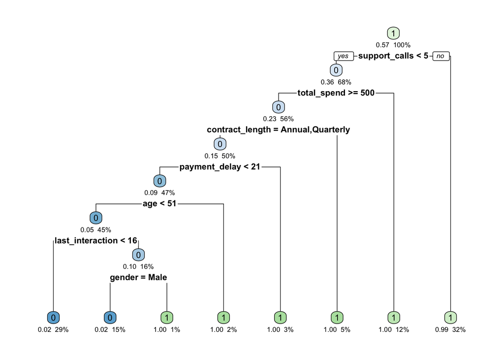

```r
# Plot the pruned tree with visible root node box
rpart.plot(tree_pruned, type = 2, extra = 106,
           faclen = 0, varlen = 0, under = TRUE,
           fallen.leaves = TRUE)
```

**Interpretation:**

*(churn = 1, stayed = 0)*

1. **Support Calls** was the most important factor:
- Customers with $\geq 5$ support calls had 99% churn rate.
- Customers with $<5$ calls had only 36% churn rate.
2. For customers with $< 5$ calls, **Total Spend** was the next key factor:
- Spending $<$ $500 led to 100% churn.
- Spending $\geq$ $500 reduced churn to 23%.
3. Among high spenders ($\geq$ $500), **Contract Length** created further distinction:
- Monthly contracts had 100% churn rate.
- Quarterly/annual contracts had only 15% churn rate.
4. For customers with longer contracts, **Payment Delay** was significant:
- Delays $\geq 21$ days let to 100% churn.
- Delays $< 21$ days reduced churn to 9%.
5. Among the lowest-risk customers, **Age**, **Last Interaction**, and **Gender** had minor effects.

## **Model Evaluation**

```r
# Make predictions on the test dataset
pred <- predict(tree_pruned, test_data, type = "class")

# Create confusion matrix
conf_matrix <- confusionMatrix(pred, test_data$churn, positive = "1")

# Print the results
print(conf_matrix)
```

```
## Confusion Matrix and Statistics
##
##           Reference
## Prediction     0     1
##          0 56840  1325
##          1   409 73674
##
##                Accuracy : 0.9869
##                  95% CI : (0.9863, 0.9875)
##     No Information Rate : 0.5671
##     P-Value [Acc > NIR] : < 2.2e-16
##
##                   Kappa : 0.9733
##
##  Mcnemar's Test P-Value : < 2.2e-16
##
##             Sensitivity : 0.9823
##             Specificity : 0.9929
##          Pos Pred Value : 0.9945
##          Neg Pred Value : 0.9772
##              Prevalence : 0.5671
##          Detection Rate : 0.5571
##    Detection Prevalence : 0.5602
##       Balanced Accuracy : 0.9876
##
##        'Positive' Class : 1
##
```

**Interpretation:**

- Overall accuracy: 98.69%
- True Positives (correctly predicted churners): 73,674
- True Negatives (correctly predicted non-churners) : 56,840
- False Positives: 409
- False Negatives: 1,325

The model showed excellent performance in both identifying churners (high sensitivity - 98.23%) and identifying non-churners (high specificity - 99.29%).

## Key Findings

1. **Support Calls** is the strongest predictor of churn ( $\geq 5$ calls - 99% churn rate).
2. **Monthly Contracts** show extremely high churn, regardless of other factors.
3. Among customers with fewer support calls, several factors led to 100% churn
- **Total spend** $<$ $500
- **Monthly contracts**
- **High payment delays** ($\geq$ 21 days)
- **Older age** ($\geq$ 51 years)

# **Customer Segmentation (K-means)**

## **Data Preprocessing**

This process primarily included label encoding, scaling, and feature selection：

```r
# Remove churn column for clustering
customer_clean <- churn %>% select(-churn)

# Convert all categorical variables to numeric
customer_clean[] <- lapply(customer_clean, function(col) {
  if (!is.numeric(col)) as.numeric(as.factor(col)) else col
})

# Check for label encoding
str(customer_clean)

# Scale the data
customer_scaled <- scale(customer_clean)

# Show scaled data (first 6 rows)
print(head(customer_scaled), digits = 2)

# create a subset
customer_scaled_subset <- customer_scaled[, c("gender", "age",
                          "total_spend", "support_calls",
                          "payment_delay", "contract_length")]
```

[output not shown]

**Why use feature selection?**

- Based on churn-related factors identified in EDA.
- Ensures segments form around relevant behavioral and demographic characteristics.
- Reducing computational demands on large dataset (n=440,832).

## **Find the Optimal Number of Clusters**

Used the Elbow Method to find the optimal k by minimizing within-cluster variation (WCSS):

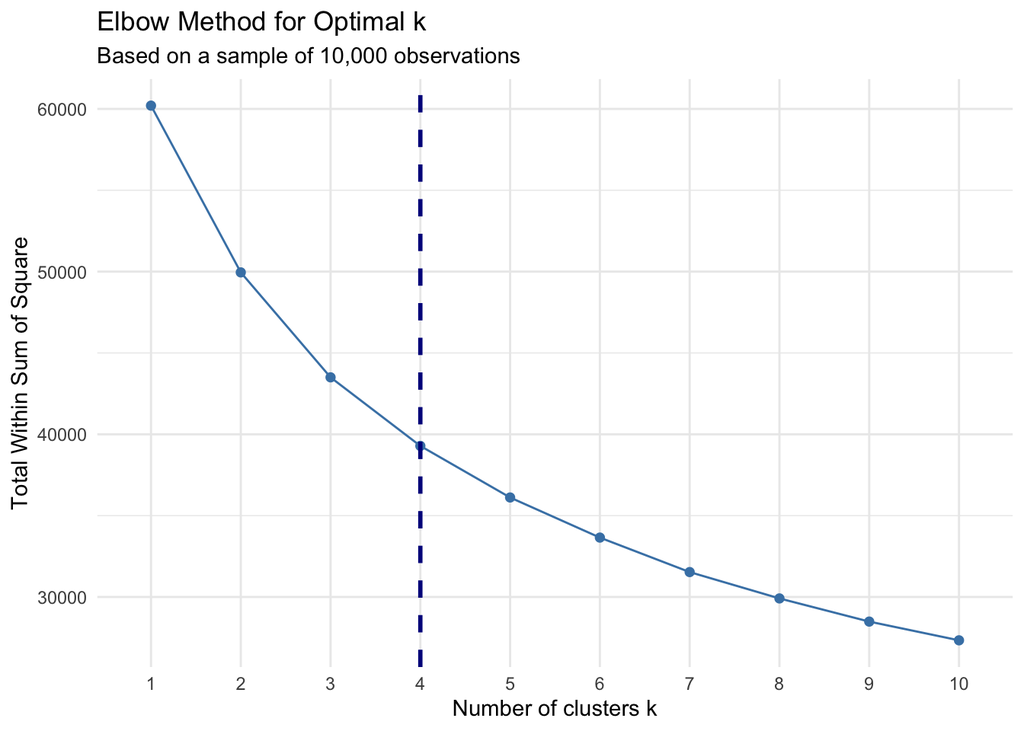

```r
# Take a sample of the data
set.seed(123)
sample_indices <- sample(nrow(customer_scaled_subset), 10000)
sample_data <- customer_scaled_subset[sample_indices, ]

# Use factoextra's function
fviz_nbclust(
  sample_data,
  FUN = function(x, k) kmeans(x, centers = k,
                              nstart = 25, iter.max = 100),
  method = "wss",
  k.max = 10
  ) +
  labs(title = "Elbow Method for Optimal k",
       subtitle = "Based on a sample of 10,000 observations") +
  theme_minimal() +
  geom_vline(xintercept = 4, linetype = "dashed",
             color = "darkblue", linewidth = 1)
```

**Interpretation:** The sharp drop in WCSS from k = 1 to 4, followed by flattening, suggests **k = 4** as optimal for balanced cluster compactness.

## **Perform K-means Clustering**

To address computational constraints, a two-stage K-means approach was used:

- **Stage 1:** Sampled a smaller subset to identify initial centroids.
- **Stage 2:** Used these centroids to initialize clustering on the full dataset.

### Initial Clustering

```r
# Using a sample for initial clustering
set.seed(123)
sample_indices1 <- sample(nrow(customer_scaled_subset), 50000)
sample_data1 <- customer_scaled_subset[sample_indices1, ]

# Perform K-means on the sample
kmeans_sample <- kmeans(sample_data1,
                        centers = 4, # based on step 3
                        nstart = 25,
                        iter.max = 100)

# Get the cluster centers
initial_centers <- kmeans_sample$centers
```

### **Final Clustering**

```r
# Use these centers for the full dataset
kmeans_result <- kmeans(customer_scaled_subset,
                        centers = initial_centers,
                        nstart = 1,
                        iter.max = 30)

# Show cluster information
cat("Cluster sizes:\n")
```

```
## Cluster sizes:
```

```r
print(table(kmeans_result$cluster))
```

```
##
##      1      2      3      4
## 109638 112530  86788 131876
```

```r
# Add the cluster assignments back to the original data
churn$cluster <- kmeans_result$cluster
churn$cluster <- as.factor(churn$cluster)
```

## **Evaluate Cluster Quality**

```r
quality_ratio <- ((kmeans_result$betweenss /
                  kmeans_result$totss) * 100)

cat("Clustering quality (between_SS / total_SS):",
     round(quality_ratio, 1), "%\n")
```

```
## Clustering quality (between_SS / total_SS): 34.7 %
```

**Interpretation:** The clustering explains about 34.7% of total variance, indicating moderate clustering quality with some within-cluster variability remaining.

## **Cluster Analysis**

### **Bar Chart: Customer Churn vs. Retention by Cluster**

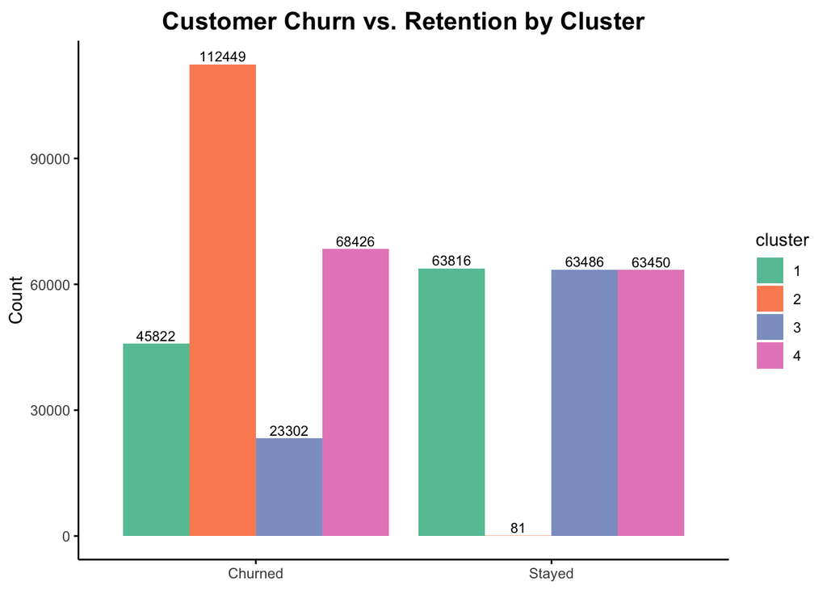

```r
# Prepare the summary table
churn_cluster_summary <- churn %>%
  group_by(churn, cluster) %>%
  summarise(count = n(), .groups = "drop") %>%
  mutate(churn = ifelse(churn == 1, "Churned", "Stayed"))

# Calculate churn rate by cluster
churn_rate_by_cluster <- churn %>%
  group_by(cluster) %>%
  summarise(
    total = n(),
    churned = sum(churn == 1),
    churn_rate = paste0(round(sum(churn == 1) / n() * 100, 2), "%"),
    .groups = "drop"
  ) %>%
  arrange(cluster)

# Plot it
ggplot(churn_cluster_summary,
       aes(x = churn, y = count, fill = cluster)) +
  geom_bar(stat = "identity", position = "dodge") +
  geom_text(aes(label = count),
            position = position_dodge(width = 0.9),
            vjust = -0.3, size = 3) +
  scale_fill_brewer(palette = "Set2") +
  labs(title = "Customer Churn vs. Retention by Cluster",
       x = NULL,
       y = "Count") +
  theme_minimal() +
  theme(plot.title = element_text(face = "bold",size = 15,
                                  hjust = 0.5,vjust = 0.5),
        panel.grid.major = element_blank(),
        panel.grid.minor = element_blank(),
        axis.line = element_line(color = "black"),
        axis.ticks = element_line(color = "black")
  )
```

```r
# Print the churn rate table
print(churn_rate_by_cluster)
```

```
## # A tibble: 4 × 4
##   cluster  total churned churn_rate
##   <fct>    <int>   <int> <chr>
## 1 1       109638   45822 41.79%
## 2 2       112530  112449 99.93%
## 3 3        86788   23302 26.85%
## 4 4       131876   68426 51.89%
```

**Cluster 2：**

- Extremely high churn rate (**99.93%)**, with only 81 customers retained.
- Represents the most critical group needing urgent attention.

**Cluster 1 & 4:**

- Elevated churn rates of **41.79%** (Cluster 1) and **51.89%** (Cluster 4).
- Over half of the customers in Cluster 4 have churned, suggesting need for proactive retention strategies.

**Cluster 3:**

- Lowest churn rate at **26.85%**, indicating a more stable and engaged customer segment.

### **Boxplots: Numerical Variables - Cluster 2 vs. Others**

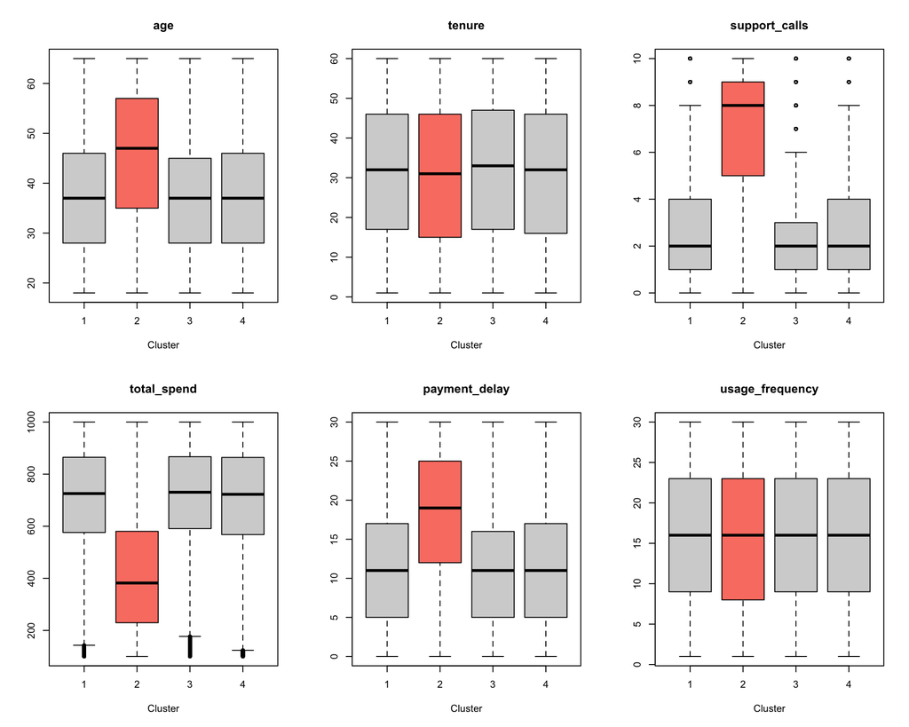

```r
# Select numerical variables
numeric_vars <- c("age", "tenure", "support_calls",
                  "total_spend", "payment_delay", "usage_frequency")

# Set up a 2x2 grid for plots
par(mfrow = c(2, 3))

# Plot it
for (var in numeric_vars) {
  boxplot(churn[[var]] ~ churn$cluster,
          col = ifelse(levels(churn$cluster) ==
                         "2", "salmon", "lightgray"),
          main = var,
          xlab = "Cluster",
          ylab = "")
}
```

**Characteristics of high-risk segment (Cluster 2):**

- **Older Demographics:** Median age of 47, skewed toward middle-aged customers.
- **High Support Calls:** Median of 8 calls, significantly higher than other clusters.
- **Lower Spending:** Median total spend around $380, despite similar usage and tenure.
- **Longer Payment Delays:** Median of 19 days, indicating persistent payment difficulties.

### **Bar Charts: Categorical Variables - Cluster 2 vs. Others**

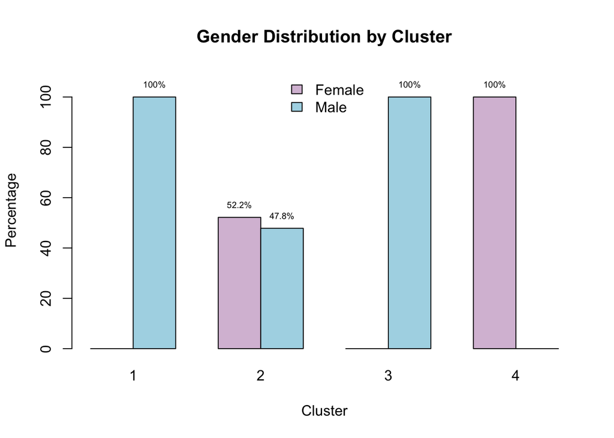

```r
# Create gender distribution plot
gender_table <- table(churn$gender, churn$cluster)
gender_percent <- prop.table(gender_table, margin = 2) * 100

# Plot the bar chart
gender_bp <- barplot(gender_percent,
        beside = TRUE,
        col = c("thistle", "lightblue"),
        main = "Gender Distribution by Cluster",
        xlab = "Cluster",
        ylab = "Percentage",
        ylim = c(0, 110),
        legend.text = c("Female", "Male"),
        args.legend = list(x = "top", bty = "n"))

# Add percentage labels to gender bars
for (i in 1:nrow(gender_percent)) {
  for (j in 1:ncol(gender_percent)) {
    if (gender_percent[i, j] >= 1) {
      text(gender_bp[i, j], gender_percent[i, j] + 5,
           paste0(round(gender_percent[i, j], 1), "%"),
           cex = 0.6)
    }
  }
}
```

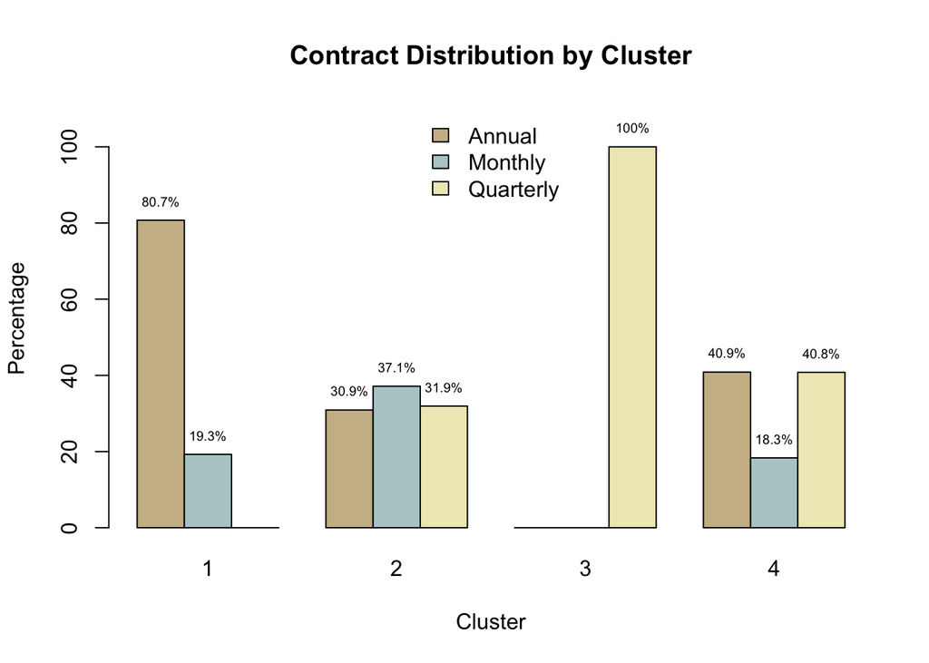

```r
# Create contract type distribution plot
contract_table <- table(churn$contract_length, churn$cluster)
contract_percent <- prop.table(contract_table, margin = 2) * 100

# Plot the bar chart
contract_bp <- barplot(contract_percent,
        beside = TRUE,
        col = c("wheat3", "lightcyan3", "lemonchiffon2"),
        main = "Contract Distribution by Cluster",
        xlab = "Cluster",
        ylab = "Percentage",
        ylim = c(0, 110),
        legend.text = c("Annual", "Monthly", "Quarterly"),
        args.legend = list(x = "top", bty = "n"))

# Add percentage labels to contract bars
for (i in 1:nrow(contract_percent)) {
  for (j in 1:ncol(contract_percent)) {
    if (contract_percent[i, j] >= 1) {
      text(contract_bp[i, j], contract_percent[i, j] + 5,
           paste0(round(contract_percent[i, j], 1), "%"),
           cex = 0.6)
    }
  }
}
```

## Key Findings

**Cluster 1 (Moderate Risk - 41.79% Churn):**

- Younger male customers, mostly on Annual contracts.
- Value-sensitive with moderate loyalty.

**Cluster 2 (High-Risk - 99.93% Churn):**

- Middle-aged customers with balanced gender, high support needs, mixed contracts, long payments delays, lower spending.
- Critical service issues and financial stress.

**Cluster 3 (Most Stable - 26.85% Churn):**

- Younger male customers on Quarterly contracts.
- Highest retention and customer loyalty.

**Cluster 4** **(At-Risk - 51.89% Churn):**

- Younger female customers, mostly on Quarterly/Annual contracts.
- Requires proactive retention despite longer contracts.

# **Integrated Insights**

**Demographics:**

- Middle-aged customers define high-risk group.
- Female customers showed a higher churn risk.

**Service Quality:**

- 5+ support calls associated with 99% churn rate.
- High-risk Cluster 2 showed highest average support calls.

**Payment Behavior:**

- Timely payments linked to low churn.
- High-risk Cluster 2 showed significantly longer payment delays.

# **Recommendations**

## Retention Strategies

1. **Support Call Alerts:**
- Create automatic alerts when customers reach 3-4 support calls
- Deploy a service recovery team before critical 5-call threshold
- Enhance AI chatbot to resolve common issues
- Address root causes of frequent support needs
2. **Spending-Based Retention:**
- Target special offers for customers spending below $500
- Develop loyalty rewards that increase with spending
- Offer volume discounts to encourage higher spending
3. **Contract Management:**
- Phase out monthly contracts or add incentives to upgrade
- Create early renewal options with benefits
4. **Payment Monitoring:**
- Send payment reminder before 21-day threshold
- Develop flexible payment options
- Offer discounts for automatic payments
5. **Demographic-Specific Approach:**
- Create age-appropriate messaging and service channels for older customers
- Create gender-specific retention campaigns for female customers
6. **Segment-Based Focus:**
- For low-risk segments: Focus on upselling, referral programs, and revenue growth, rather than churn prevention alone

## Model Improvement

1. **Enhance Decision Tree:**
- Test ensemble methods like Random Forest or Bagging
- Retrain model regularly with new customer data
2. **Refine Clustering:**
- Adjust cluster numbers based on business knowledge
- Add new features and test different feature combinations
3. **Implementation Testing:**
- Conduct A/B testing of retention strategies
- Create real-time dashboards to monitor churn risk
4. **Expand Analysis:**
- Analyze customer feedback and support conversations
- Identify service quality issues causing high support calls